# **Analiza i wizualizacja danych**

## Lab 8. Biblioteka matplotlib, część 1 - teoria

### 1. Wprowadzenie

Interface `pyplot` biblioteki `matplotlib` zawiera szereg funkcji, umożliwiających stworzenie zarówno podstawowych, jak i złożonych wykresów. Podstawowe elementy, które mogą zostać zawarte na wykresie wprowadzone zostały w ćwiczeniu *(Pandas cz.2)* - warto jednak zaznajomić się ze wszystkimi możliwymi składowymi wykresu/ryciny oraz poznać ich angielskie nazwy (m.in. figures, grid etc.), które są przydatne szczególne podczas korzystania z parametrów funkcji.  
Poniższa grafika, stworzona z pomocą modułu matplotlib (https://matplotlib.org/stable/gallery/showcase/anatomy.html), przedstawia wszystkie te elementy:

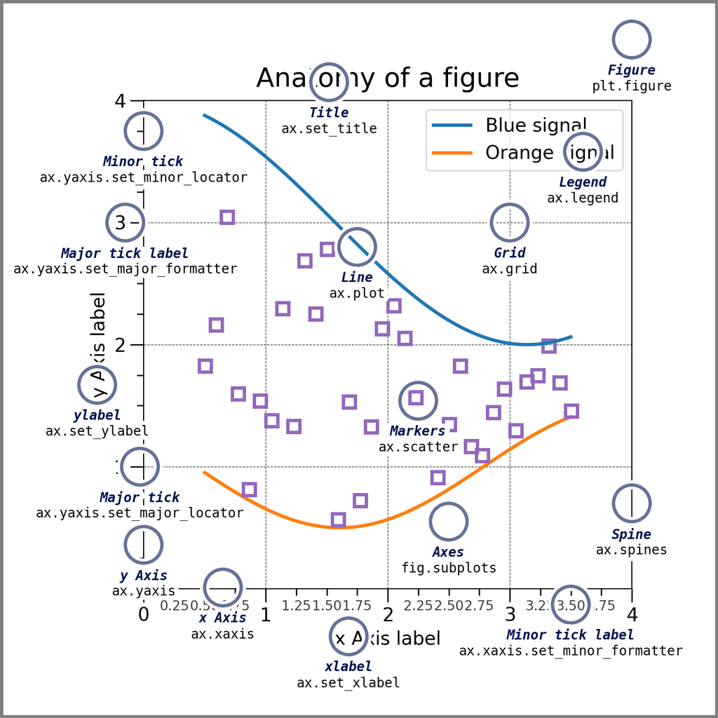

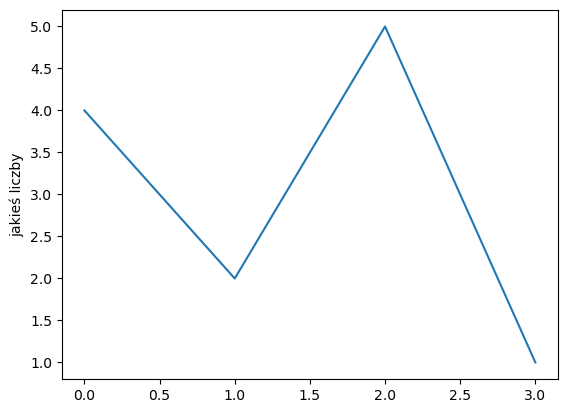

```python
import matplotlib.pyplot as plt

# bardzo prosty wykres liniowy
plt.plot([4, 2, 5, 1])
plt.ylabel('jakieś liczby')
plt.show()

#Powyższy fragment kodu po uruchomieniu generuje bardzo prosty wykres:
```

Wektor przekazanych wartości przedstawia **oś Y**, z kolei **oś X** została wygenerowana automatycznie i przyjmuje wartości [0,1,2,3]

### 2. Style wykresów

##### **1. Wykres domyślny - liniowy**

Możemy stworzyć wykresy przekazując dwa wektory wartości najpierw dla wektora x, następnie y. Dodatkowo możemy przekazać parametr w postaci wartości typu string, który określi styl wykresu, np. `'ro-'`.  
Wszelkie możliwości można sprawdzić na stronie dokumentacji: https://matplotlib.org/stable/api/_as_gen/matplotlib.pyplot.plot.html

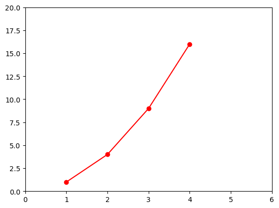

```python
import matplotlib.pyplot as plt
plt.plot([1, 2, 3, 4], [1, 4, 9, 16], 'ro-')

# tutaj określamy min i max zakres osi (w postaci [xmin, xmax, ymin, ymax])
plt.axis([0, 6, 0, 20])
plt.show()
```

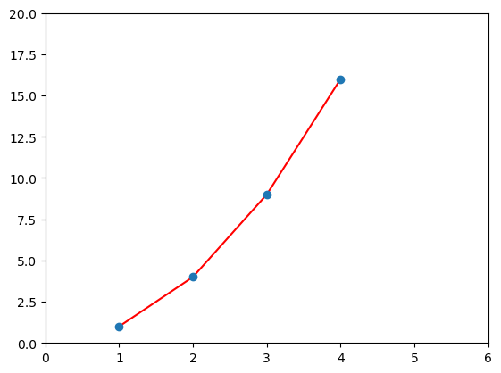

```python
import matplotlib.pyplot as plt

# możemy też ustawiać różne kolory dla poszczególnych elementów nakładając na siebie dwa wykresy
plt.plot([1, 2, 3, 4], [1, 4, 9, 16], 'r')
plt.plot([1, 2, 3, 4], [1, 4, 9, 16], 'o')

plt.axis([0, 6, 0, 20])
plt.show()
```

Za pomocą pojedynczego wywołania funkcji plot() możemy wygenerować wiele wykresów na jednym "płótnie" (ang. canvas) każdorazowo podając niezbędne wartości: wartości dla osi x, wartości dla osi y, styl wykresu

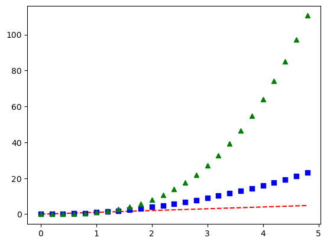

```python
import matplotlib.pyplot as plt
import numpy as np

# bazowy wektor wartości
t = np.arange(0., 5., 0.2)

plt.plot(t, t, 'r--', t, t**2, 'bs', t, t**3, 'g^')
plt.show()
```

Wykresy mogą być też dodawane do jednego płótna definicja po definicji zamiast w pojedynczym wywołaniu funkcji plot()

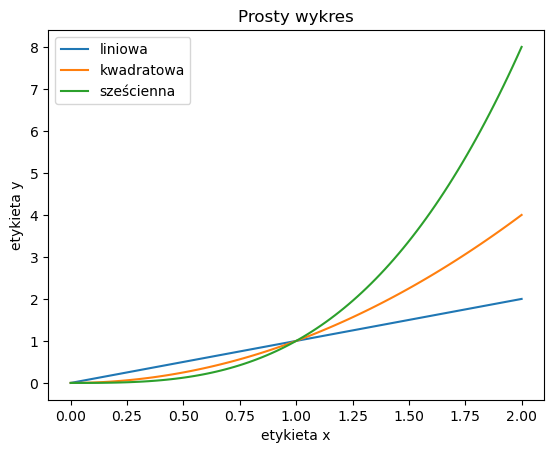

```python
import matplotlib.pyplot as plt
import numpy as np

# metoda linspace(start,stop,num) zwraca zadaną liczbę próbek (num) w zakresie [start-stop]
x = np.linspace(0, 2, 100)

# parametr label określa etykietę danego wykresu w legendzie
plt.plot(x, x, label='liniowa')
plt.plot(x, x**2, label='kwadratowa')
plt.plot(x, x**3, label='sześcienna')

# etykiety osi
plt.xlabel('etykieta x')
plt.ylabel('etykieta y')

# tytuł wykresu
plt.title("Prosty wykres")

# włączamy pokazywanie legendy
plt.legend()

plt.show()
```

Do stworzenia wykresów funkcji trygonometrycznych możemy wykorzystać metody znajdujące się w bibliotece numpy, która wykonuje operacje na całym wektorze (bez potrzeby używania pętli). Przy odpowiednio dużej ilości „próbek” wykres będzie gładki.

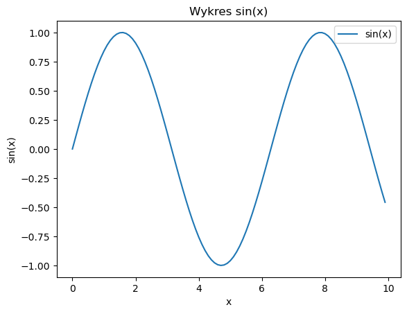

```python
import matplotlib.pyplot as plt
import numpy as np

x = np.arange(0, 10, 0.1)
s = np.sin(x)  # kąt w radianach
plt.plot(x, s, label='sin(x)')

# etykiety osi
plt.xlabel('x')
plt.ylabel('sin(x)')

# tytuł wykresu
plt.title("Wykres sin(x)")

# umieszczamy legendę na wykresie
plt.legend()

plt.show()
```

**Poeksperymentuj z ilością wartości wektora funkcji sin(x).**

##### **2. Wykres punktowy**

Za pomocą wykresu możemy graficznie przedstawić dane przechowywane w formie słownika jak i w DataFrame’ach.  
**np.random.randn()** – jako argumenty przyjmuje wymiary tablicy; funkcja generuje liczby pseudolosowe z rozkładu normalnego (Gaussa), średniej 0 i odchyleniu standardowym 1 (innymi słowy, zwraca liczby z rozkładu normalnego)

```python
import matplotlib.pyplot as plt
import numpy as np

data = {'a': np.arange(50),  # 1, 2, 3, ..., 48, 49
        'c': np.random.randint(0, 50, 50),
        'd': np.random.randn(50)}
data
```

```
{'a': array([ 0,  1,  2,  3,  4,  5,  6,  7,  8,  9, 10, 11, 12, 13, 14, 15, 16,
        17, 18, 19, 20, 21, 22, 23, 24, 25, 26, 27, 28, 29, 30, 31, 32, 33,
        34, 35, 36, 37, 38, 39, 40, 41, 42, 43, 44, 45, 46, 47, 48, 49]),
 'c': array([ 9,  1, 41, 13, 36,  7, 14,  1,  2, 36, 42, 32, 35,  1, 40, 10, 40,
        12, 10, 29, 46, 16, 43, 40,  9, 41, 17, 47, 29, 42, 19, 10, 43, 36,
        28, 42, 39, 30, 43, 31,  2, 20,  2, 12, 39, 19, 15, 33, 35,  3]),
 'd': array([-0.4517818 , -0.79775241, -0.01718239,  0.923298  , -1.28573376,
         0.02438453,  1.14151019,  0.43614234, -0.524618  , -0.10317486,
         0.47664661,  0.51306889, -0.17655812,  1.36871234, -0.09811974,
         0.13406895,  0.99589225,  1.64837693,  0.09306445,  0.24305555,
         1.52403165, -0.78852439, -1.58489385, -0.23276341, -0.87684591,
        -0.71739519, -0.82781743, -0.89918873,  0.84368661,  0.36351994,
         0.4138186 , -1.09093554,  1.01654659,  1.26430883,  0.73958474,
        -0.56160168, -0.56414101, -1.91452529, -0.7485595 , -0.0702481 ,
         1.35155213,  0.02334465, -0.18444686,  0.47695996, -0.04714905,
         0.6657877 , -0.52584197,  0.02362177, -0.78231152, -1.49780964])}
```

```python
data['b'] = data['a'] + 10 * np.random.randn(50) # dodanie nowego klucza ‘b’
data['d'] = np.abs(data['d']) * 100  # nadpisanie wartości klucza ‘d’
```

```python
data['b']
```

```
array([-0.64143933, 20.50602576,  2.97300819,  0.3914853 , 12.33903099,
        1.75662765, 10.19817608, 21.37208923, 12.62310486, -4.98709233,
       16.94991393, 16.58070739,  8.32827595, -7.65148194, 15.022276  ,
       29.5217663 , 18.56767145, 26.73591977, 10.36968771, 24.97678074,
       13.58006949,  4.88682796, 16.56862536, 16.85787956, 14.68158476,
       38.88688322, 45.67736538, 35.77057325, 46.45673681, 28.16399565,
       44.84029886, 34.09520906, 14.72043628, 34.85676152, 32.047604  ,
       35.92869386, 35.46145814, 45.37878094, 50.14281876, 35.25366212,
       46.43750467, 21.82936035, 40.10798259, 30.88628051, 58.74446322,
       36.30738944, 55.98610079, 59.43980257, 54.75864368, 43.53192557])
```

```python
data['d']
```

```
array([ 45.1781805 ,  79.77524075,   1.71823887,  92.32980015,
       128.57337565,   2.43845299, 114.15101917,  43.61423418,
        52.46180023,  10.31748619,  47.6646609 ,  51.30688851,
        17.65581233, 136.87123357,   9.81197369,  13.40689508,
        99.58922534, 164.83769284,   9.30644493,  24.30555545,
       152.40316474,  78.85243931, 158.4893848 ,  23.27634071,
        87.68459115,  71.73951885,  82.78174334,  89.91887347,
        84.36866125,  36.35199398,  41.38186046, 109.09355434,
       101.65465919, 126.43088252,  73.95847426,  56.16016849,
        56.41410057, 191.45252922,  74.85595042,   7.02481026,
       135.15521298,   2.33446461,  18.44468573,  47.69599626,
         4.71490475,  66.57876956,  52.58419704,   2.3621769 ,
        78.23115201, 149.78096435])
```

Aby przekazać parametry wykresu należy dodać parametr `data` (jest on tu niezbędny, bo w ten sposób przekazujemy **całość danych** zebranych w słowniku/DataFrame). Dane dostępne są poprzez etykiety – etykietami w powyższym przykładzie są: `'a'`, `'b'`, `'c'`, `'d'`. To oznacza, że 'a' jako parametr przekazujemy tak jakbyśmy przekazywali `data['a']` itd.  
Parametr `c` to skrót od `color`, tutaj przekazywany w formie wektora wartości kolorów dla każdej kolejnej wartości wykresu. Parametr `s` to `scale` - określa rozmiar, w tym przypadku punktu, dla każdej kolejnej wartości wektora wykresu.

Dla pierwszego punktu wykresu będą brane poniższe wartości:

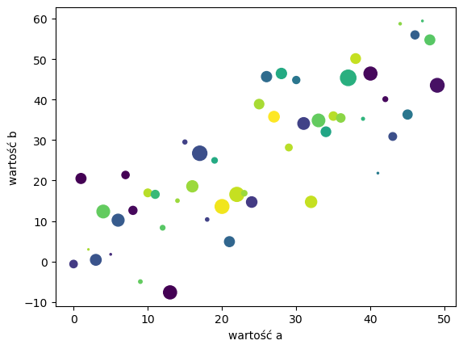

```python
plt.scatter('a', 'b', c='c', s='d', data=data)
plt.xlabel('wartość a')
plt.ylabel('wartość b')
plt.show()
```

```python
print(f"a={data['a'][0]}, b={data['b'][0]}, c={data['c'][0]}, d={data['d'][0]}")
```

```
a=0, b=-0.6414393349046933, c=9, d=45.17818049683262
```

##### **3. Podwykresy**

Podwykresy pozwalają na umieszczanie na jednym płótnie wielu wykresów.  
Podajemy wymiary, czyli liczbę wierszy oraz liczbę kolumn, w których umieszczone zostaną podwykresy. Służy do tego funkcja `subplot`, która przyjmuje 3 argumenty (nrows, ncols, index).  
Odpowiednio jest to: ilość wierszy, ilość kolumn oraz indeks definiowanego wykresu (indeksy rozpoczynają się od 1 i kończą na *nrows* * *ncols*).

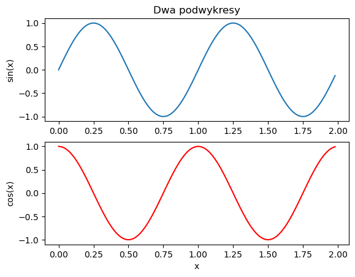

```python
import numpy as np
import matplotlib.pyplot as plt


x1 = np.arange(0.0, 2.0, 0.02)
x2 = np.arange(0.0, 2.0, 0.02)

y1 = np.sin(2 * np.pi * x1)
y2 = np.cos(2 * np.pi * x2)


plt.subplot(2, 1, 1)
plt.plot(x1, y1, '-')
plt.title('Dwa podwykresy')
plt.ylabel('sin(x)')

plt.subplot(2, 1, 2)
plt.plot(x2, y2, 'r-')
plt.xlabel('x')
plt.ylabel('cos(x)')

plt.show()
```

Możemy również pomijać umieszczanie wykresu w danym miejscu siatki.

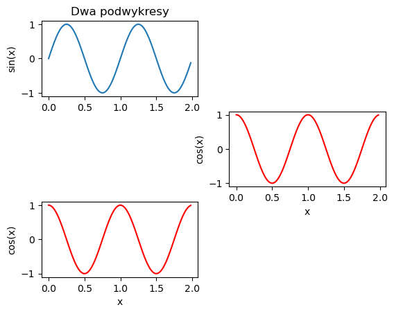

```python
import numpy as np
import matplotlib.pyplot as plt


x1 = np.arange(0.0, 2.0, 0.02)
x2 = np.arange(0.0, 2.0, 0.02)
y1 = np.sin(2 * np.pi * x1)
y2 = np.cos(2 * np.pi * x2)

# oznacza, że mamy tutaj do czynienia z gridem 3x2 (3 wiersze, 2 kolumny)
# i definiujemy wykres o indeksie 1
plt.subplot(3, 2, 1)
plt.plot(x1, y1, '-')
plt.title('Dwa podwykresy')
plt.ylabel('sin(x)')

# wykres o indeksie 4
plt.subplot(3, 2, 4)
plt.plot(x2, y2, 'r-')
plt.xlabel('x')
plt.ylabel('cos(x)')

# wykres o indeksie 5
plt.subplot(3, 2, 5)
plt.plot(x2, y2, 'r-')
plt.xlabel('x')
plt.ylabel('cos(x)')

plt.show()
```

##### **4. Inne typy wykresów**

Poniższy listing przedstawia prosty przykład wykresu **słupkowego**:

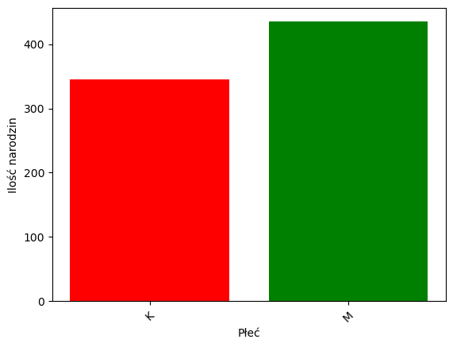

```python
import numpy as np
import matplotlib.pyplot as plt

etykiety = ['K', 'M']
wartosci = [345, 435]
c = ['red', 'green']

plt.bar(etykiety, wartosci, color=c)

# możemy również zmienić np. kierunek tekstu etykiet słupków
plt.xticks(rotation=45)
plt.ylabel('Ilość narodzin')
plt.xlabel('Płeć')
plt.show()
```

Popularnym typem wykresów dla zaprezentowania rozkładów prawdopodobieństwa są **histogramy**:

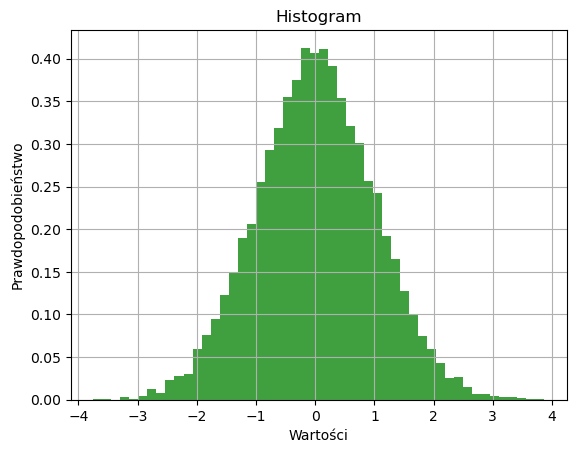

```python
import numpy as np
import matplotlib.pyplot as plt

x = np.random.randn(10000)

plt.hist(x, bins=50, facecolor='g', alpha=0.75, density=True)

plt.xlabel('Wartości')
plt.ylabel('Prawdopodobieństwo')
plt.title('Histogram')
# wyświatlanie siatki
plt.grid(True)
plt.show()
```

- **bins** oznacza ilość „koszy” czyli słupków, do których mają wpadać wartości z wektora x
- **facecolor** oznacza kolor słupków
- **alpha** to stopień przezroczystości wykresu
- **density** oznacza czy suma ilości zostanie znormalizowana do rozkładu prawdopodobieństwa, czyli przedział 0,1

Poniższy listing przedstawia przykład wykresu **kołowego**:

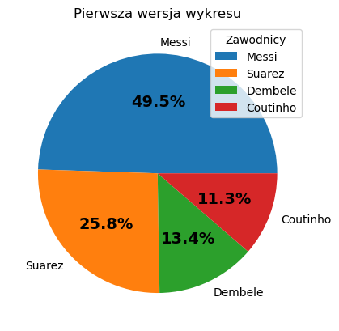

```python
import numpy as np
import matplotlib.pyplot as plt

zawodnicy = ['Messi', 'Suarez', 'Dembele', 'Coutinho']
bramki = [48, 25, 13, 11]


# pierwsza wersja wykresu
wedges, texts, autotexts = plt.pie(bramki, labels=zawodnicy,
                                   autopct=lambda pct: "{:.1f}%".format(pct), textprops=dict(color="black"))
plt.setp(autotexts, size=14, weight="bold")
plt.title("Pierwsza wersja wykresu")
plt.legend(title='Zawodnicy')
plt.show()
```

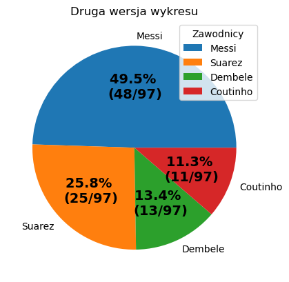

```python
# druga wersja wykresu
def prepare_label(pct, br):
    absolute = int(np.ceil(pct / 100. * np.sum(br)))
    return "{:.1f}% \n({}/{})".format(pct, absolute, sum(bramki))


wedges, texts, autotexts = plt.pie(bramki, labels=zawodnicy,
                                   autopct=lambda pct: prepare_label(pct, bramki), textprops=dict(color="black"))
plt.setp(autotexts, size=14, weight="bold")
plt.title("Druga wersja wykresu")
plt.legend(title='Zawodnicy')
plt.show()
```